# Ejercicio 2: Strings

Juan Barriola y Sofía Perini

12 de Septiembre de 2020

1.a Leer el dataset

```r
tiburones <- read_csv("~/EEA-2020/Fuentes/ataques_tiburones.csv")
glimpse(tiburones)
```

```
## Observations: 5,897
## Variables: 22
## $ `Case Number`            <chr> "2016.03.10", "2016.03.04", "2016.03.03…
## $ Date                     <chr> "10-Mar-2016", "04-Mar-2016", "Reported…
## $ Year                     <dbl> 2016, 2016, 2016, 2016, 2016, 2016, 201…
## $ Type                     <chr> "Unprovoked", "Unprovoked", "Unprovoked…
## $ Country                  <chr> "Fiji", "USA", "AUSTRALIA", "BRAZIL", "…
## $ Area                     <chr> "Vanua Levu", "Florida", "South Austral…
## $ Location                 <chr> NA, "Ocean Reef Park, Singer Island, Pa…
## $ Activity                 <chr> "Diving for beche-de-mer", NA, "Fishing…
## $ Name                     <chr> "Maika Tabua", "male", "Lee Taplin", "R…
## $ Sex                      <chr> "M", "M", "M", "M", "M", "M", "F", "M",…
## $ Age                      <chr> "45", "12", NA, "41", "21", "31", NA, "…
## $ Injury                   <chr> "FATAL", "Superficial injury to foot", …
## $ `Fatal (Y/N)`            <chr> "Y", "N", "N", "N", "N", "N", "N", "N",…
## $ Time                     <chr> "Afternoon", "Afternoon", "Midnight", N…
## $ Species                  <chr> NA, NA, "Bronze whaler", "Sandtiger sha…
## $ `Investigator or Source` <chr> "Fiji Sun, 3/12/2016", "WPTV. 3/4/2016"…
## $ pdf                      <chr> "2016.03.10-Tabua.pdf", "2016.03.04-OCP…
## $ `href formula`           <chr> "http://sharkattackfile.net/spreadsheet…
## $ href                     <chr> "http://sharkattackfile.net/spreadsheet…
## $ `Case Number_1`          <chr> "2016.03.10", "2016.03.04", "2016.03.03…
## $ `Case Number_2`          <chr> "2016.03.10", "2016.03.04", "2016.03.03…
## $ `original order`         <dbl> 5898, 5897, 5896, 5895, 5894, 5893, 589…
```

```r
tiburones = tiburones %>% select(`Case Number`, Date, Country)
```

## Limpieza de la variable país

2. Obtener los valores únicos de la variable *Country* (país)

```r
# Creamos una lista con los valores de Country para ver si hay algunos problemas
tiburones %>%
  select(Country) %>% # Seleccionamos la variable del pais
  arrange(Country) %>% # La ordenamos
  distinct() %>% # Nos quedamos con los valores unicos
  as.list()
```

```
## $Country
##   [1] "ADMIRALTY ISLANDS"              "ALGERIA"
##   [3] "AMERICAN SAMOA"                 "ANDAMAN / NICOBAR ISLANDAS"
##   [5] "ANGOLA"                         "ANTIGUA"
##   [7] "ARGENTINA"                      "ARUBA"
##   [9] "ASIA?"                          "ATLANTIC OCEAN"
##  [11] "AUSTRALIA"                      "AZORES"
##  [13] "BAHAMAS"                        "BAHREIN"
##  [15] "BANGLADESH"                     "BARBADOS"
##  [17] "BAY OF BENGAL"                  "BELIZE"
##  [19] "BERMUDA"                        "Between PORTUGAL & INDIA"
##  [21] "BRAZIL"                         "BRITISH ISLES"
##  [23] "BRITISH NEW GUINEA"             "BRITISH VIRGIN ISLANDS"
##  [25] "BRITISH WEST INDIES"            "BURMA"
##  [27] "CANADA"                         "CAPE VERDE"
```

[output cut: 85 more lines]

Hay varios problemas, pero veamos dos:

- Hay algunos nombres que no están en mayúscula
- Hay algunos nombres que tienen espacios en blanco a izquierda y derecha

3.a Llevar los nombres a mayúscula

```r
tiburones <- tiburones %>%
  mutate(pais = str_to_upper(Country))
head(tiburones, 10)
```

| Case Number | Date | Country | pais |
| --- | --- | --- | --- |
| 2016.03.10 | 10-Mar-2016 | Fiji | FIJI |
| 2016.03.04 | 04-Mar-2016 | USA | USA |
| 2016.03.03.R | Reported 03-Mar-2016 | AUSTRALIA | AUSTRALIA |
| 2016.03.02 | 02-Mar-2016 | BRAZIL | BRAZIL |
| 2016.02.22 | 22-Feb-2016 | NEW CALEDONIA | NEW CALEDONIA |
| 2016.02.19 | 19-Feb-2016 | NEW CALEDONIA | NEW CALEDONIA |
| 2016.02.12 | 12-Feb-2016 | DOMINICAN REPUBLIC | DOMINICAN REPUBLIC |
| 2016.02.10.R | Reported 10-Feb-2016 | CAYMAN ISLANDS | CAYMAN ISLANDS |
| 2016.02.10 | 10-Feb-2016 | AUSTRALIA | AUSTRALIA |
| 2016.02.05 | 05-Feb-2016 | AUSTRALIA | AUSTRALIA |

3.b Quitar los espacios en blanco a izquierda y derecha

```r
tiburones <- tiburones %>%
  mutate(pais = str_trim(pais, side = "both"))
```

3.c Quitar el signo de pregunta que aparace al final de ciertos nombres.

Como el “?” es un carácter especial en las expresiones regulares (REGEX), hay que utilizar “/?” para reemplazarlo.

```r
tiburones = tiburones %>%
  mutate(pais = str_replace(pais, pattern = "/?", replacement = ""))
```

## Limpieza variable fecha

4. Revisar la variable *Date* y evaluar qué problemas presenta esta variable para normalizarla

```r
tiburones %>% select(Date) %>% distinct()
```

| Date |
| --- |
| 10-Mar-2016 |
| 04-Mar-2016 |
| Reported 03-Mar-2016 |
| 02-Mar-2016 |
| 22-Feb-2016 |
| 19-Feb-2016 |
| 12-Feb-2016 |
| Reported 10-Feb-2016 |
| 10-Feb-2016 |
| 05-Feb-2016 |

[output cut: 5074 more lines]

Vemos que la variable Date viene en muchos casos con la palabra “Reported” lo cual nos impide que podamos tratar esa expresión como fecha.

5. Eliminar la palabra “Reported” (con su espacio en blanco) de la fecha

```r
# Hacemos la limpieza de la fecha como vimos más arriba
tiburones <- tiburones %>%
  mutate(fecha = str_replace_all(string = Date, pattern =  "Reported ", replacement = ""))
glimpse(tiburones)
```

```
## Observations: 5,897
## Variables: 5
## $ `Case Number` <chr> "2016.03.10", "2016.03.04", "2016.03.03.R", "2016.…
## $ Date          <chr> "10-Mar-2016", "04-Mar-2016", "Reported 03-Mar-201…
## $ Country       <chr> "Fiji", "USA", "AUSTRALIA", "BRAZIL", "NEW CALEDON…
## $ pais          <chr> "FIJI", "USA", "AUSTRALIA", "BRAZIL", "NEW CALEDON…
## $ fecha         <chr> "10-Mar-2016", "04-Mar-2016", "03-Mar-2016", "02-M…
```

6. Convertir la variable fecha de string a datetime. Crear las variables de año, mes y día

```r
tiburones <- tiburones %>% mutate(fecha= dmy(fecha))
```

El mensaje indica que no pudo convertir a fecha 891 registros.

```r
# Extraemos variables de la fecha
tiburones <- tiburones %>%
  mutate(año = year(fecha), # Obtener el año
         mes = month(fecha,label = TRUE), # Obtener el nombre del mes
         dia = day(fecha))# Obtener el día
glimpse(tiburones)
```

```
## Observations: 5,897
## Variables: 8
## $ `Case Number` <chr> "2016.03.10", "2016.03.04", "2016.03.03.R", "2016.…
## $ Date          <chr> "10-Mar-2016", "04-Mar-2016", "Reported 03-Mar-201…
## $ Country       <chr> "Fiji", "USA", "AUSTRALIA", "BRAZIL", "NEW CALEDON…
## $ pais          <chr> "FIJI", "USA", "AUSTRALIA", "BRAZIL", "NEW CALEDON…
## $ fecha         <date> 2016-03-10, 2016-03-04, 2016-03-03, 2016-03-02, 2…
## $ año           <dbl> 2016, 2016, 2016, 2016, 2016, 2016, 2016, 2016, 20…
## $ mes           <ord> mar, mar, mar, mar, feb, feb, feb, feb, feb, feb, …
## $ dia           <int> 10, 4, 3, 2, 22, 19, 12, 10, 10, 5, 4, 29, 28, 25,…
```

## Gráficos

7. Quedarse con los ataques desde el año 1800 en adelante

```r
tiburones_filtro <- tiburones %>% filter(año >=1800)
```

8. Crear un dataframe con la cantidad de ataques totales por región desde el 1800 en adelante

```r
ataques_por_region = tiburones_filtro %>%
                        group_by(Country) %>%
                        count() %>%
                        ungroup() # Evitar que mantenga el grupo para otras operaciones
```

9. Realizar un gráfico de barras para los 20 países con mayor cantidad de ataques

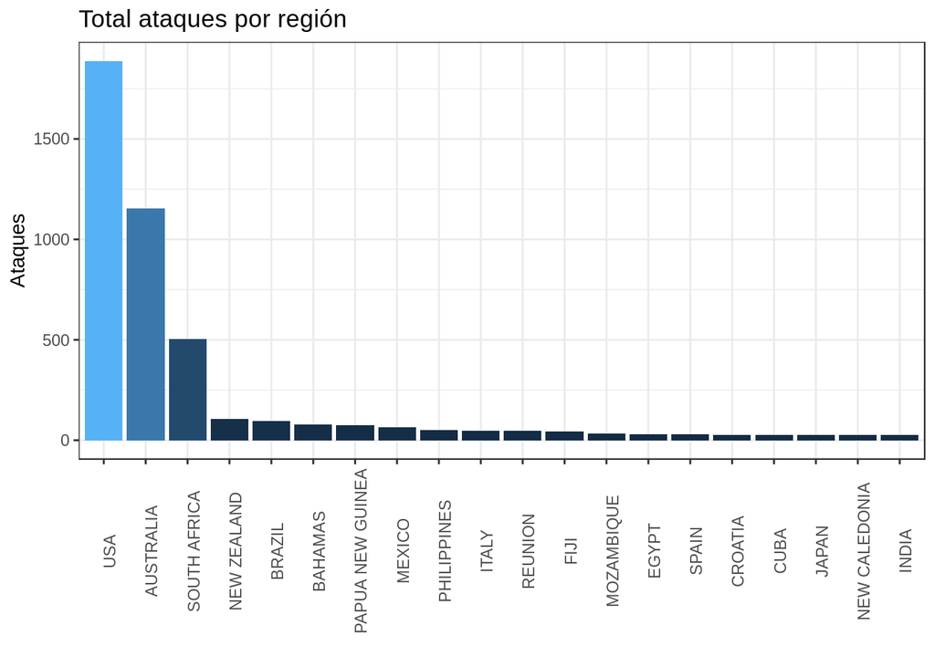

```r
ataques_por_region %>%
  top_n(20) %>% # la función top_n nos permite seleccionar los n registros con más ataques
  ggplot(., aes(x=reorder(Country, -n), y=n,fill=n)) + # la función reorder permite reordenar las regiones de mayor a menor por ataques
  geom_bar(stat='identity') +
  theme_bw() +
  theme(legend.position = 'none', axis.text.x = element_text(angle = 90)) +
  labs(title='Total ataques por región', y='Ataques', x='')
```

10. Realizar un gráfico de la evolución de ataques por año desde 1800

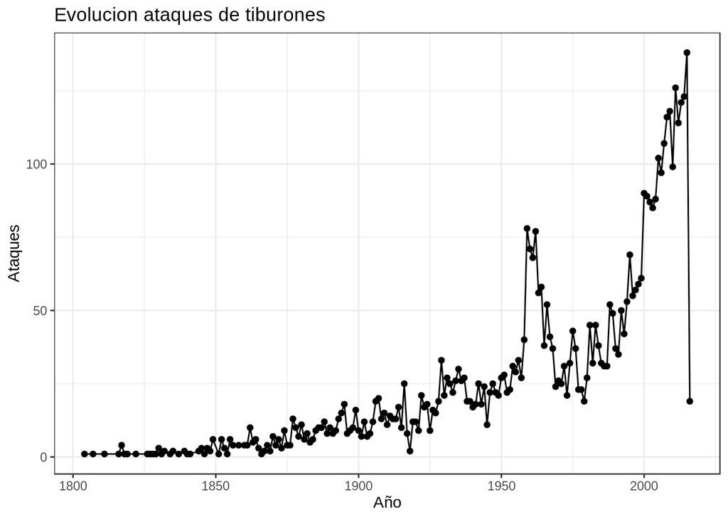

```r
ggplot(tiburones_filtro, aes(año)) +
  geom_line(stat = "count") +
  geom_point(stat='count') +
  theme_bw() +
  labs(title='Evolucion ataques de tiburones', x='Año', y='Ataques')
```

11. Realizar un gráfico del total de ataques por mes para AUSTRALIA y USA (Estados Unidos) para construir el ciclo anual de ataques en estos países

```r
tiburones_aus_usa <- tiburones_filtro %>% filter(pais %in% c("AUSTRALIA","USA"))
```

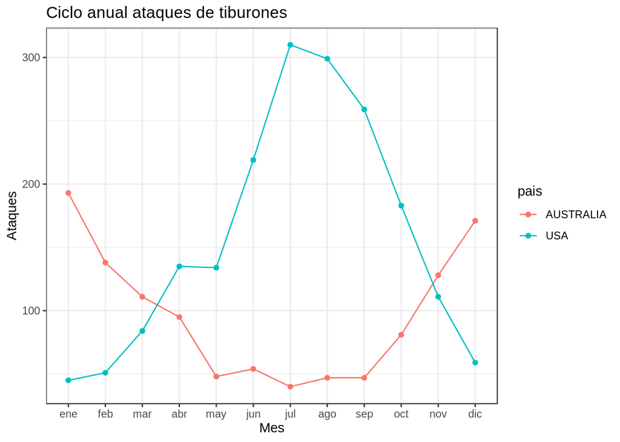

```r
ggplot(tiburones_aus_usa, aes(mes,color=pais, group=pais)) +
  geom_line(stat = "count") +
  geom_point(stat='count') +
  theme_bw() +
  labs(title='Ciclo anual ataques de tiburones', x='Mes', y='Ataques')
```